# main_code

```python
import json
import os
from IPython.display import display, Markdown

def insert_notebook_toc(max_lvl=2):
    # Пытаемся автоматически найти имя текущего .ipynb файла
    notebook_files = [f for f in os.listdir('.') if f.endswith('.ipynb')]
    if not notebook_files:
        return "Файлы .ipynb не найдены в текущей директории."

    filename = notebook_files[0]

    with open(filename, 'r', encoding='utf-8') as f:
        nb_data = json.load(f)

    toc_lines = ["# Содержание\n"]

    for cell in nb_data.get('cells', []):
        if cell.get('cell_type') == 'markdown':
            for line in cell.get('source', []):
                line_stripped = line.strip()
                if line_stripped.startswith('#'):
                    level = len(line_stripped) - len(line_stripped.lstrip('#'))
                    if level <= max_lvl:
                        title = line_stripped.lstrip('#').strip()
                        anchor = title.lower().replace(' ', '-').replace('.', '')
                        indent = "  " * (level - 1)
                        toc_lines.append(f"{indent}* [{title}](#{anchor})")

    return "\n".join(toc_lines)

display(Markdown(insert_notebook_toc(max_lvl=2)))
```

Содержание

- Задача №0 - Подготовка датасета

  - Поиск подходящих данных

- Задача №1

  - Выбрать набор данных

  - Анализ предметной задачи и постановка

  - Машиночитаемый вид, ресемплинг и базовая предобработка

  - Разведочный анализ данных (EDA))

  - Выводы

- Задача №2

  - Подготовка данных

  - Модели

  - Доверительный интервал (AutoARIMA))

  - Статистика

  - Вывод

- Задача №3

  - Детекция аномалий во временном ряду

  - Feature Engineering и инициализация фреймворка MLForecast

  - Доверительный интервал (XGBoost))

  - Статистика

  - Вывод

- Задача №4

# Задача №0 - Подготовка датасета

```python
import os
import pandas as pd
```

Данные разбиты на **8 основных колонок**:

1. **`square_id`** (int) — Идентификатор квадратной ячейки географической сетки.
2. **`timestamp`** (int) — Время начала интервала в миллисекундах (Unix Epoch Time).
3. **`country_code`** (int) — Телефонный код страны, с которой связано взаимодействие.
4. **`sms_in`** (float) — Индекс активности входящих SMS внутри ячейки.
5. **`sms_out`** (float) — Индекс активности исходящих SMS из ячейки.
6. **`call_in`** (float) — Индекс активности входящих звонков.
7. **`call_out`** (float) — Индекс активности исходящих звонков.
8. **`internet`** (float) — Индекс активности интернет-соединений (трафика).

```python
columns = [
    'square_id',
    'timestamp_ms',
    'country_code',
    'sms_in',
    'sms_out',
    'call_in',
    'call_out',
    'internet'
]

# Путь ко всем файлам
folder_path = './Telecommunications_TN/'
file_list = [
    os.path.join(folder_path, f)
    for f in os.listdir(folder_path)
    if f.startswith('sms-call-internet-tn') and os.path.isfile(os.path.join(folder_path, f))
]
print(f"Всего файлов: {len(file_list)}")
```

```
Всего файлов: 62
```

```python
use_files = file_list[0:]

df = pd.concat(
    (pd.read_csv(file, sep='\t', names=columns, header=None) for file in use_files),
    ignore_index=True
)
df.head()
```

|  | square_id | timestamp_ms | country_code | sms_in | sms_out | call_in | call_out | internet |
| --- | --- | --- | --- | --- | --- | --- | --- | --- |
| 0 | 10000 | 1383260400000 | 0 | 0.109442 | NaN | NaN | 0.021888 | NaN |
| 1 | 10000 | 1383260400000 | 39 | 1.000626 | 1.264627 | 0.087554 | 0.219587 | 10.168455 |
| 2 | 10000 | 1383260400000 | 49 | NaN | NaN | NaN | NaN | 0.021888 |
| 3 | 10000 | 1383261000000 | 0 | 0.193200 | NaN | NaN | NaN | NaN |
| 4 | 10000 | 1383261000000 | 39 | 0.648294 | 1.058651 | 0.175108 | 0.153219 | 11.867058 |

```python
# Обработка
# Время
df['datetime'] = pd.to_datetime(df['timestamp_ms'], unit='ms')
df = df.drop(columns=['timestamp_ms'])

# Корректировка часового пояса, переход от UTC к Италии
df['datetime'] = df['datetime'].dt.tz_localize('UTC').dt.tz_convert('Europe/Rome').dt.tz_localize(None)

# Заполнение нулями пропуски
df = df.fillna(0)

# Расчет суммарных показателей активности
df['sms'] = df['sms_in'] + df['sms_out']
df['calls'] = df['call_in'] + df['call_out']
df = df.drop(columns=['sms_in', 'sms_out', 'call_in', 'call_out'])

# Группировка и агрегация по временным интервалам и ячейкам сетки
df = df[['datetime', 'square_id', 'internet', 'sms', 'calls']].groupby(['datetime', 'square_id'], as_index=False).sum()
```

```python
df.head(10)
```

|  | datetime | square_id | internet | sms | calls |
| --- | --- | --- | --- | --- | --- |
| 0 | 2013-11-01 | 38 | 11.537291 | 0.869410 | 0.033146 |
| 1 | 2013-11-01 | 39 | 12.843910 | 0.861527 | 0.163483 |
| 2 | 2013-11-01 | 40 | 14.445915 | 1.156612 | 0.096205 |
| 3 | 2013-11-01 | 154 | 20.264727 | 1.039509 | 0.348010 |
| 4 | 2013-11-01 | 155 | 19.117608 | 0.815392 | 0.247139 |
| 5 | 2013-11-01 | 156 | 12.933668 | 0.625922 | 0.146034 |
| 6 | 2013-11-01 | 157 | 18.235721 | 0.531821 | 0.120534 |
| 7 | 2013-11-01 | 158 | 6.930469 | 0.534357 | 0.234407 |
| 8 | 2013-11-01 | 159 | 4.830810 | 0.256506 | 0.070775 |
| 9 | 2013-11-01 | 160 | 1.176256 | 0.558389 | 0.024680 |

```python
df.info()
```

```
<class 'pandas.core.frame.DataFrame'>
RangeIndex: 55756626 entries, 0 to 55756625
Data columns (total 5 columns):
 #   Column     Dtype
---  ------     -----
 0   datetime   datetime64[ns]
 1   square_id  int64
 2   internet   float64
 3   sms        float64
 4   calls      float64
dtypes: datetime64[ns](1), float64(3), int64(1)
memory usage: 2.1 GB
```

```python
df.describe(include='all')
```

|  | datetime | square_id | internet | sms | calls |
| --- | --- | --- | --- | --- | --- |
| count | 55756626 | 5.575663e+07 | 5.575663e+07 | 5.575663e+07 | 5.575663e+07 |
| mean | 2013-12-02 00:04:45.651677952 | 6.070078e+03 | 1.535147e+01 | 2.845407e+00 | 1.840998e+00 |
| min | 2013-11-01 00:00:00 | 3.800000e+01 | 0.000000e+00 | 0.000000e+00 | 0.000000e+00 |
| 25% | 2013-11-16 12:10:00 | 4.139000e+03 | 2.389234e+00 | 9.678350e-02 | 1.649602e-02 |
| 50% | 2013-12-02 00:10:00 | 6.192000e+03 | 6.663155e+00 | 7.688661e-01 | 3.611487e-01 |
| 75% | 2013-12-17 12:00:00 | 8.109000e+03 | 1.552111e+01 | 2.730323e+00 | 1.696463e+00 |
| max | 2014-01-01 23:50:00 | 1.145400e+04 | 6.852491e+03 | 1.581077e+03 | 8.976119e+02 |
| std | NaN | 2.600417e+03 | 4.558328e+01 | 1.096544e+01 | 7.408040e+00 |

## Поиск подходящих данных

Идея сразу найти:

1. Сектор (квадрат) без пропусков во времени (чтобы в дальнейшем на зполнять пропуски).
2. Из секторов без пропусков выбрать с максимальным средним.

```python
unique_dates_count = df['datetime'].nunique()
print(f"Всего уникальных данных времени: {unique_dates_count}")
unique_square_count = df['square_id'].nunique()
print(f"Всего уникальных 'square_id' или квадратов: {unique_dates_count}")

# Частота встречаемости каждого square_id
square_counts = df['square_id'].value_counts()
# Отбор 'square_id' которые встречаются ровно unique_dates_count раз
valid_squares = square_counts[square_counts == unique_dates_count].index
# Фильтруем данные по отобранным square_id
filtered_df = df[df['square_id'].isin(valid_squares)]
# Группировка по square_id и счет среднее internet, получение best_square_id
sort_filt_square_id = filtered_df.groupby('square_id')['internet'].mean()

best_square_id = sort_filt_square_id.idxmax()
print(f"Подходящее square_id: {best_square_id}")
sort_filt_square_id.sort_values(ascending=False).head()
```

```
Всего уникальных данных времени: 8928
Всего уникальных 'square_id' или квадратов: 8928
Подходящее square_id: 5200
```

```
square_id
5200    1453.640521
5201    1253.355642
5084    1200.786478
5083     744.223465
5317     621.531301
Name: internet, dtype: float64
```

# Задача №1

## Выбрать набор данных

Для выполнения **Итогового задания** выбран открытый набор данных *Telecom Italia Big Data Challenge* (регион: Провинция **Трентино — TN**).

Суть данных - телекоммуникационная активность населения, зафиксированная базовыми станциями сотовой связи.

В качестве **целевой переменной** выбрана `internet`, в статье про датасет точных единиц измерения этого параметра нету, но:

- *"`Internet` a CDR (Call Detail Records) is generated each time a user starts an Internet connection or ends an Internet connection. During the same connection a CDR is generated if the connection lasts for more than 15 min or the user transferred more than 5 MB."*
- Для упрощения единицы измерения у `Internet` будут **CDR**, что в свою очередь можно представить как → $ Трафик (МБ) ≈ CDR (кол-во) \times 5 МБ$

[figure not shown]

*Квадрат 5200 (темно-зеленый)*

## Анализ предметной задачи и постановка

**Горизонт прогнозирования.** Учитывая дискретизацию данных в 10 минут, можно установить горизонт прогнозирования на 1 сутки вперед. В сутках $24 \times 6 = 144$ интервала. Таким образом, длина горизонта $H = 144$ шага.

**Необходимость глобальных моделей.** *пока nope*

**Режим функционирования.** Офлайн (батч-прогнозирование). Модели обучаются на исторических данных за прошедшие дни и строят пакетный прогноз на следующие сутки для планирования нагрузки на сеть.

**Метрики качества.** MAE, MSE, RMSE

## Машиночитаемый вид, ресемплинг и базовая предобработка

```python
select_id = 5200

df_select = df[df['square_id'] == select_id].copy()

# Формирование df как в forecasting
df_ts = df_select[['datetime', 'internet']].rename(columns={'datetime': 'ds', 'internet': 'y'})
df_ts = df_ts.reset_index(drop=True)
df_ts['unique_id'] = select_id
print(f"=== Количество записей для квадрата '{select_id}': {len(df_ts)}")
print(df_ts.dtypes)

# Проверка непрерывности сетки - Resampling
df_ts.set_index('ds').resample('10min').asfreq()  # Установка ds как индекса
if df_ts['y'].isna().sum() != 0:
    print('\nResampling - пропуски есть')
    missing_count = df_ts['y'].isna().sum()
    print(f"Обнаружено пропущенных временных интервалов: {missing_count}")
    df_ts['y'] = df_ts['y'].interpolate(method='linear')
    df_ts['unique_id'] = df_ts['unique_id'].fillna(select_id).astype(int)
else:
    print('\nResampling - пропусков нету')

print(f"\n=== Итоговое количество записей после обработки: {len(df_ts)}")
print(df_ts.dtypes)

print("\nHead\n", df_ts.head())
print("\nTail\n", df_ts.tail())
```

```
=== Количество записей для квадрата '5200': 8928
ds           datetime64[ns]
y                   float64
unique_id             int64
dtype: object

Resampling - пропусков нету

=== Итоговое количество записей после обработки: 8928
ds           datetime64[ns]
y                   float64
unique_id             int64
dtype: object

Head
                    ds            y  unique_id
0 2013-11-01 00:00:00  1282.762132       5200
1 2013-11-01 00:10:00   886.509522       5200
2 2013-11-01 00:20:00   937.466917       5200
3 2013-11-01 00:30:00   987.067983       5200
4 2013-11-01 00:40:00   763.797187       5200

Tail
                       ds            y  unique_id
8923 2014-01-01 23:10:00   897.958752       5200
8924 2014-01-01 23:20:00  1783.704140       5200
8925 2014-01-01 23:30:00   461.682798       5200
8926 2014-01-01 23:40:00  1860.404363       5200
8927 2014-01-01 23:50:00   580.396173       5200
```

## Разведочный анализ данных (EDA)

```
→ Визуализация исходного временного ряда трафика
```

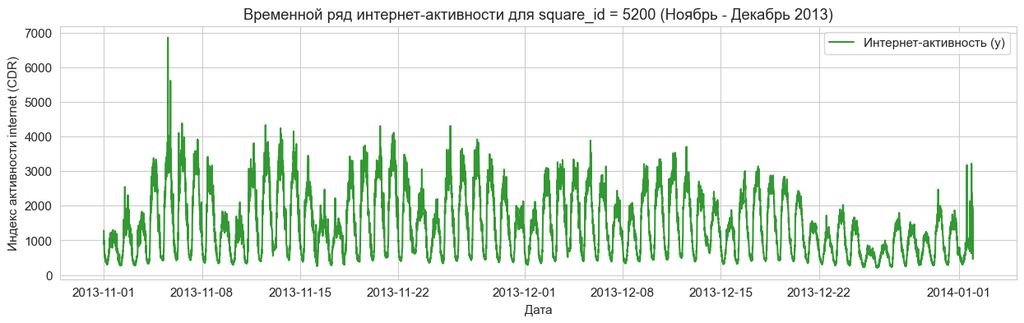

```python
import os
import matplotlib.pyplot as plt
import seaborn as sns
import holidays
from statsmodels.tsa.seasonal import seasonal_decompose
from statsmodels.tsa.stattools import adfuller
from statsmodels.graphics.tsaplots import plot_acf, plot_pacf

# 1. Настройка стилей отображения графиков
sns.set_style('whitegrid')
plt.rcParams['figure.figsize'] = (14, 6)
plt.rcParams['font.size'] = 11

# Подготовим копию датафрейма с временным индексом для EDA анализа
df_eda = df_ts.copy()
df_eda.set_index('ds', inplace=True)

# Опеределяем параметры сетки: 10 минут -> в 1 сутках 144 интервала
steps_per_day = 144  # 24 часа * 6 интервалов

print("→ Визуализация исходного временного ряда трафика")
plt.figure(figsize=(15, 4))
plt.plot(df_eda.index, df_eda['y'], color='green', alpha=0.8, label='Интернет-активность (y)')
plt.title('Временной ряд интернет-активности для square_id = 5200 (Ноябрь - Декабрь 2013)')
plt.xlabel('Дата')
plt.ylabel('Индекс активности internet (CDR)')
plt.legend()
plt.show()
```

```
→ Генерация календарных фич и анализ сезонности
```

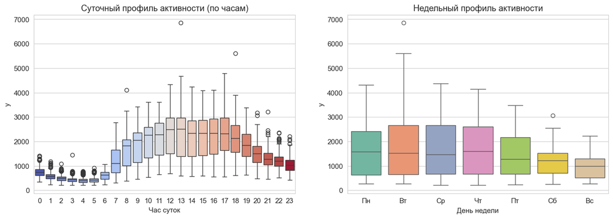

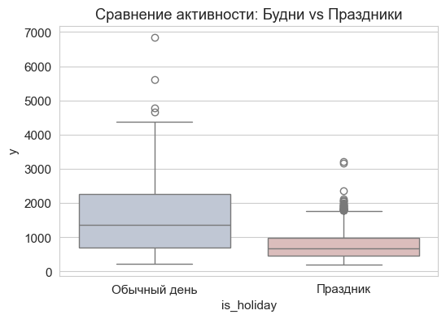

```python
print("→ Генерация календарных фич и анализ сезонности")
df_eda['hour'] = df_eda.index.hour
df_eda['day_of_week'] = df_eda.index.dayofweek
df_eda['month'] = df_eda.index.month

# Добавление праздников Италии (производственный календарь)
it_holidays = holidays.IT(years=[2013, 2014])
df_eda['is_holiday'] = df_eda.index.to_series().dt.date.apply(lambda x: x in it_holidays).astype(int)

# Графики распределения активности по часам и дням недели
fig, axes = plt.subplots(1, 2, figsize=(16, 5))
sns.boxplot(data=df_eda, x='hour', y='y', ax=axes[0], palette='coolwarm', hue='hour', legend=False)
axes[0].set_title('Суточный профиль активности (по часам)')
axes[0].set_xlabel('Час суток')
axes[0].set_ylabel('y')

sns.boxplot(data=df_eda, x='day_of_week', y='y', ax=axes[1], palette='Set2', hue='day_of_week', legend=False)
axes[1].set_title('Недельный профиль активности')
axes[1].set_xlabel('День недели')
axes[1].set_xticks(range(7))
axes[1].set_xticklabels(['Пн', 'Вт', 'Ср', 'Чт', 'Пт', 'Сб', 'Вс'])
axes[1].set_ylabel('y')
plt.show()

# Анализ праздников
plt.figure(figsize=(6, 4))
sns.boxplot(data=df_eda, x='is_holiday', y='y', palette='vlag', hue='is_holiday', legend=False)
plt.title('Сравнение активности: Будни vs Праздники')
plt.xticks([0, 1], ['Обычный день', 'Праздник'])
plt.show()
```

```
→ Классическая декомпозиция (Аддитивная модель)
Первый Пн: 2013-11-04 00:00:00
```

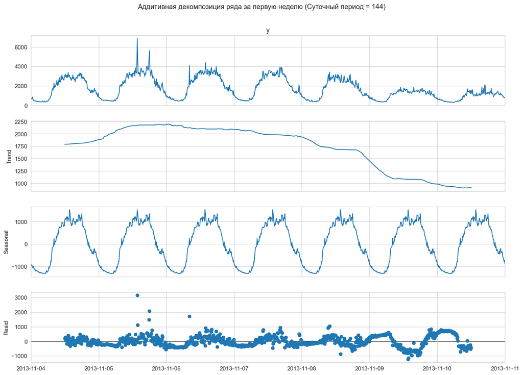

```
Просмотр для всего ряда
```

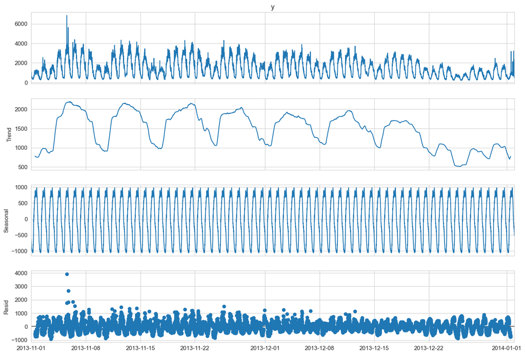

```python
print("→ Классическая декомпозиция (Аддитивная модель)")
# Проверка структуры на примере окна в неделю для наглядности отображения
start_date  = df_eda[df_eda['day_of_week'] == 0].index[0]  # Поиск первого Пн
print(f"Первый Пн: {start_date}")
end_date = start_date + pd.Timedelta(days=7)

decomp_sample = df_eda.loc[start_date:end_date, 'y']
decomposition = seasonal_decompose(decomp_sample, model='additive', period=steps_per_day)

fig = decomposition.plot()
fig.set_size_inches(14, 10)
plt.suptitle('Аддитивная декомпозиция ряда за первую неделю (Суточный период = 144)', y=1.02)
plt.show()


print("Просмотр для всего ряда")
decomposition = seasonal_decompose(df_eda['y'], model='additive', period=steps_per_day)

fig = decomposition.plot()
fig.set_size_inches(14, 10)
plt.show()
```

```
→ Корреляционный анализ (ACF и PACF)
```

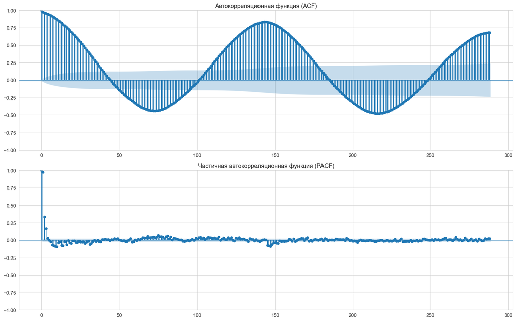

```python
print("→ Корреляционный анализ (ACF и PACF)")
# Оцениваем глубину в 2 суток (144 * 2 = 288 лагов)
fig, ax = plt.subplots(2, 1, figsize=(16, 10))
plot_acf(df_eda['y'], lags=steps_per_day * 2, ax=ax[0], title="Автокорреляционная функция (ACF)")
plot_pacf(df_eda['y'], lags=steps_per_day * 2, ax=ax[1], title="Частичная автокорреляционная функция (PACF)", method='ywm')
plt.tight_layout()
plt.show()
```

```python
print("→ Проверка стационарности. Тест Дики-Фуллера")
adf_result = adfuller(df_eda['y'].values)
print(f"Статистика ADF: {adf_result[0]:.4f}")
print(f"p-value: {adf_result[1]:.4e}")
print("Критические значения:")
for key, value in adf_result[4].items():
    print(f" * {key}: {value:.4f}")

# нулевая гипотеза о единичном корне = нестационарен
if adf_result[1] < 0.05:
    print("\nВЫВОД: Ряд СТАЦИОНАРЕН (p-value < 0.05). Нулевая гипотеза о наличии единичного корня отвергается.")
    print("Ряд не требует дифференцирования (взятия разностей) перед подачей в линейные модели.")
else:
    print("\nВЫВОД: Ряд НЕСТАЦИОНАРЕН (p-value >= 0.05).")
```

```
→ Проверка стационарности. Тест Дики-Фуллера
Статистика ADF: -16.6260
p-value: 1.6819e-29
Критические значения:
 * 1%: -3.4311
 * 5%: -2.8619
 * 10%: -2.5669

ВЫВОД: Ряд СТАЦИОНАРЕН (p-value < 0.05). Нулевая гипотеза о наличии единичного корня отвергается.
Ряд не требует дифференцирования (взятия разностей) перед подачей в линейные модели.
```

```python
# Сохранить обработанные данные
os.makedirs('data', exist_ok=True)

save_path = os.path.join('data', f'telecom_square_{select_id}_cleaned.csv')
save_path_extra = os.path.join('data', f'telecom_square_{select_id}_cleaned_expanded.csv')

df_ts.to_csv(save_path, index=False)
df_eda.to_csv(save_path_extra, index=False)

print(f"Преобразованные данные участка {select_id} сохранены, путь: {save_path}")
print(df_eda.shape)
df_eda.head()
```

```
Преобразованные данные учатка 5200 сохранены, путь: data\telecom_square_5200_cleaned.csv
(8928, 6)
```

| ds | y | unique_id | hour | day_of_week | month | is_holiday |
| --- | --- | --- | --- | --- | --- | --- |
| 2013-11-01 00:00:00 | 1282.762132 | 5200 | 0 | 4 | 11 | 1 |
| 2013-11-01 00:10:00 | 886.509522 | 5200 | 0 | 4 | 11 | 1 |
| 2013-11-01 00:20:00 | 937.466917 | 5200 | 0 | 4 | 11 | 1 |
| 2013-11-01 00:30:00 | 987.067983 | 5200 | 0 | 4 | 11 | 1 |
| 2013-11-01 00:40:00 | 763.797187 | 5200 | 0 | 4 | 11 | 1 |

## Выводы

В ходе разведочного анализа выбранного временного ряда интернет-трафика (square_id = 5200) была установлена его устойчивая временная структура.

Суточный профиль нагрузки (ЧНН) характеризуется классической для телекоммуникационных данных формой: минимальные значения приходятся на ночные часы (период сна абонентов), после чего активность резко возрастает и достигает пика в дневное время, а вечером наблюдается постепенный спад.

Недельный профиль подтверждает разницу в поведении пользователей: активность в выходные дни, когда большинство абонентов находятся дома, заметно отличается от будничной.

Анализ автокорреляционной функции (ACF) и ее частной версии (PACF) выявил высокую зависимость текущих значений ряда от предыдущих. При этом применение теста Дики-Фуллера (ADF) позволило отвергнуть гипотезу о наличии единичного корня (p-value < 0.05), что формально говорит о стационарности ряда. Это указывает на то, что ряд не требует дифференцирования для использования в большинстве линейных моделей.

# Задача №2

Изучить основные методы предсказания ВР в фреймворке (ARIMA, ETS, Theta prophet) в форматах ручного и автоподбора параметров.

Провести обоснованный выбор (бектестинг, вероятностное предсказание, анализ остатков и другие техники) для выбранного временного ряда

```python
import numpy as np
import pandas as pd
import holidays
import matplotlib.pyplot as plt
from statsforecast import StatsForecast
from statsforecast.models import (
    AutoARIMA,
    AutoETS,
    AutoTheta,
    Naive
)
from utilsforecast.losses import mae, mse, rmse
from utilsforecast.evaluation import evaluate

np.random.seed(1)
```

```python
file_path = 'data/telecom_square_5200_cleaned.csv'
df_ts = pd.read_csv(file_path, index_col=False)
try:
    df_ts = df_ts.drop(columns='Unnamed: 0')
except:
    pass
print(df_ts.head())
```

[output not shown]

## Подготовка данных

Я урезал датасет (начало: с 1-ого Пн, конец: там был новый год, при взятии данных с этих дат обучение было ужасным)

```
df_ts - head
                   ds           y  unique_id  hour  day_of_week  is_weekend  \
0 2013-11-04 00:00:00  646.695936       5200     0            0           0
1 2013-11-04 00:10:00  682.688973       5200     0            0           0
2 2013-11-04 00:20:00  640.407509       5200     0            0           0
3 2013-11-04 00:30:00  842.972689       5200     0            0           0
4 2013-11-04 00:40:00  661.532571       5200     0            0           0

   is_holiday
0           0
1           0
2           0
3           0
4           0
Размер всей выборки: 5328, (дней во взятом датасете: 37.0)
Размер обучающей выборки: 5184, (дней в train: 36.0)
Размер тестовой выборки: 144 (ровно 1 сутки)
```

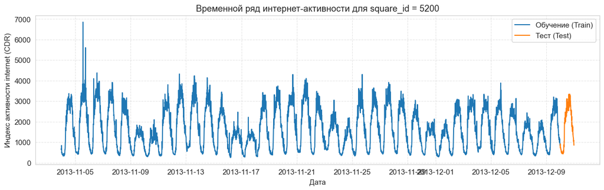

```python
# Данные под Nixtla
df_ts['ds'] = pd.to_datetime(df_ts['ds'])
df_ts['y'] = df_ts['y'].astype(float)
df_ts['unique_id'] = df_ts['unique_id'].astype(int)

# Для выбора старта
df_mod = df_ts.copy()
df_mod.set_index('ds', inplace=True)
df_mod['hour'] = df_mod.index.hour
df_mod['day_of_week'] = df_mod.index.dayofweek
# df_mod['month'] = df_mod.index.month
df_mod['is_weekend'] = df_mod['day_of_week'].isin([5, 6]).astype(int)
it_holidays = holidays.IT(years=[2013, 2014])
df_mod['is_holiday'] = df_mod.index.to_series().dt.date.apply(lambda x: x in it_holidays).astype(int)

# Даты ограничения датасета
start_date  = df_mod[df_mod['day_of_week'] == 0].index[0]  # Поиск первого Пн
mid_date = '2013-12-10' # Вт в декабре (посмотрел в календарь)
end_date = pd.to_datetime(mid_date) + pd.Timedelta(days=1)

#
df_ts = df_mod.reset_index().copy()
print(f"df_ts - head\n{df_ts.head()}")

# Определение горизонтов
SEASON = steps_per_day  # 144 (24час*60мин/10мин)
horizon = SEASON

# Решил укоротить, тк конец датасета выпадал на новый год. Там проиходит естественный спад, боюсь на малой выборки это плохо отразиться
df_ts = df_ts[(start_date <= df_ts['ds']) & (df_ts['ds'] < end_date)]

df_train = df_ts[(start_date <= df_ts['ds']) & (df_ts['ds'] < mid_date)].copy()
df_test = df_ts[(mid_date <= df_ts['ds']) & (df_ts['ds'] < end_date)].copy()

print(f"Размер всей выборки: {df_ts.shape[0]}, (дней во взятом датасете: {df_ts.shape[0]/steps_per_day})")
print(f"Размер обучающей выборки: {df_train.shape[0]}, (дней в train: {df_train.shape[0]/steps_per_day})")
print(f"Размер тестовой выборки: {df_test.shape[0]} (ровно 1 сутки)")

plt.figure(figsize=(15, 4))
plt.plot(df_train['ds'], df_train['y'], label='Обучение (Train)')
plt.plot(df_test['ds'], df_test['y'], label='Тест (Test)')
plt.title('Временной ряд интернет-активности для square_id = 5200')
plt.xlabel('Дата')
plt.ylabel('Индекс активности internet (CDR)')
plt.legend()
plt.grid(True, linestyle='--', alpha=0.5)
plt.show()
```

## Модели

```python
import warnings
warnings.filterwarnings("ignore", category=UserWarning)

# Инициализируем список базовых и автоматических моделей
models = [
    Naive(),
    AutoARIMA(season_length=SEASON, approximation=True),    # approximation=True существенно ускоряет расчет
    AutoETS(season_length=SEASON, model='ZMN'),             # ZMN автоматически подбирает тип тренда/сезона
    AutoTheta(season_length=SEASON)
]

models_list = ['Naive', 'AutoARIMA', 'AutoETS', 'AutoTheta']

# Создаем объект StatsForecast
sf = StatsForecast(
    models=models,
    freq='10min',   # Частота данных — 10 минут
    n_jobs=-1
)

print("→ Накапливаем историю и обучаем модели")

# Забираем из df_test абсолютно все ваши календарные колонки
X_df_test = df_test[[col for col in df_test.columns if col != 'y']]

# Метод fit_predict совмещает подбор параметров и генерацию прогноза на заданный горизонт
df_forecast = sf.fit_predict(df=df_train, h=horizon, X_df=X_df_test)

# Объединяем прогноз с реальными тестовыми значениями для последующего анализа
# df_eval = df_test.merge(df_forecast, on=['unique_id', 'ds'])
df_eval = df_test[['unique_id', 'ds', 'y']].merge(df_forecast, on=['unique_id', 'ds'])

print("Прогнозы успешно построены!")
df_eval.shape
df_eval.head()
```

```
→ Накапливаем историю и обучаем модели
Прогнозы успешно построены!
```

|  | unique_id | ds | y | Naive | AutoARIMA | AutoETS | AutoTheta |
| --- | --- | --- | --- | --- | --- | --- | --- |
| 0 | 5200 | 2013-12-10 00:00:00 | 900.766381 | 844.936456 | 790.880334 | 855.898823 | 767.007182 |
| 1 | 5200 | 2013-12-10 00:10:00 | 735.569373 | 844.936456 | 739.297570 | 836.415582 | 709.232860 |
| 2 | 5200 | 2013-12-10 00:20:00 | 911.667448 | 844.936456 | 666.574665 | 818.639811 | 681.797189 |
| 3 | 5200 | 2013-12-10 00:30:00 | 756.652489 | 844.936456 | 664.636023 | 802.397628 | 678.104587 |
| 4 | 5200 | 2013-12-10 00:40:00 | 722.218302 | 844.936456 | 634.302695 | 787.536031 | 629.945552 |

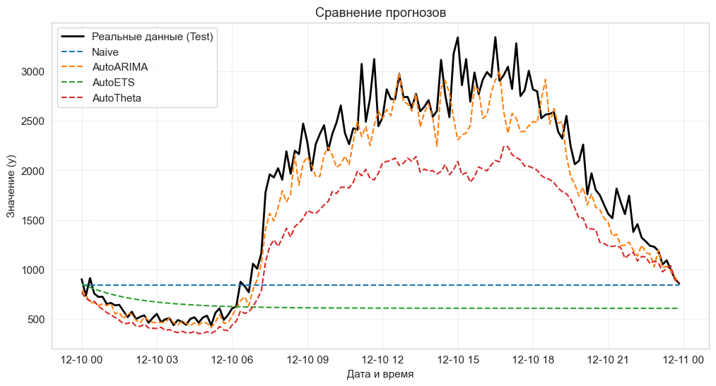

```python
plt.figure(figsize=(12, 6))
plt.plot(df_eval['ds'], df_eval['y'], label='Реальные данные (Test)', color='black', linewidth=2)
# Отрисовка прогнозов каждой модели
plt.plot(df_eval['ds'], df_eval['Naive'], label='Naive', linestyle='--')
plt.plot(df_eval['ds'], df_eval['AutoARIMA'], label='AutoARIMA', linestyle='--')
plt.plot(df_eval['ds'], df_eval['AutoETS'], label='AutoETS', linestyle='--')
plt.plot(df_eval['ds'], df_eval['AutoTheta'], label='AutoTheta', linestyle='--')

plt.title(f'Сравнение прогнозов')
plt.xlabel('Дата и время')
plt.ylabel('Значение (y)')
plt.grid(True, linestyle=':', alpha=0.8)
plt.legend()
plt.show()
```

**Кросс-валидация и бектестинг**

Чтобы выбор модели был максимально обоснованным

```python
import warnings
warnings.filterwarnings("ignore", category=SyntaxWarning)

print("→ Запуск процедуры Кросс-валидации (Бектестинг)")

# Проведем 3 шага кросс-валидации с шагом в 1 сутки (144 интервала)
df_cv = sf.cross_validation(
    df=df_ts,
    h=horizon,
    step_size=SEASON,
    n_windows=3
)
```

```
→ Запуск процедуры Кросс-валидации (Бектестинг)
```

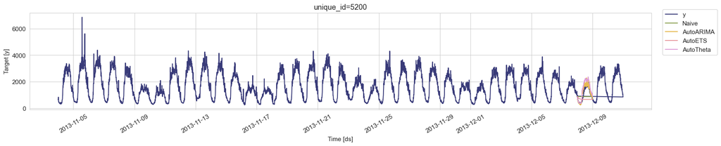

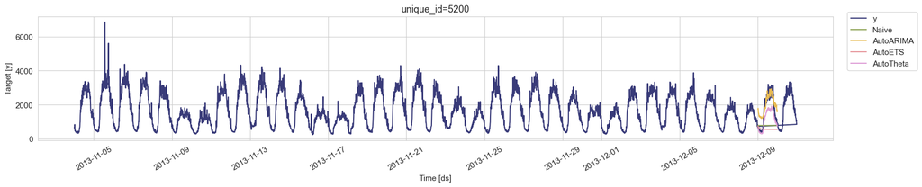

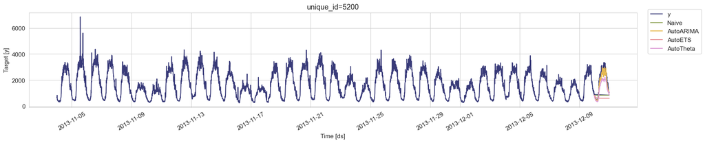

```python
cutoff = df_cv['cutoff'].unique()

for k in range(len(cutoff)):
    cv = df_cv[df_cv['cutoff'] == cutoff[k]]
    display(StatsForecast.plot(df_ts, cv.loc[:, cv.columns != 'cutoff']))
```

```python
print("Метрики для каждого фолда по отдельности:")
def evaluate_performance(df):
    metrics = [mae, mse, rmse]
    models_list = ['Naive', 'AutoARIMA', 'AutoETS', 'AutoTheta']
    return evaluate(df, metrics=metrics, models=models_list)

# Считаем метрики по фолдам
cv_results = df_cv.groupby('cutoff').apply(evaluate_performance).reset_index(level=0, drop=True)
display(cv_results)

print("\nУсредненные метрики по итогам бектестинга:")
# Группируем по метрике, чтобы посчитать среднее отдельно для MAE, MSE и RMSE
mean_metrics = cv_results.groupby('metric').mean(numeric_only=True)
display(mean_metrics)
```

```
Метрики для каждого фолда по отдельности:
```

|  | unique_id | cutoff | metric | Naive | AutoARIMA | AutoETS | AutoTheta |
| --- | --- | --- | --- | --- | --- | --- | --- |
| 0 | 5200 | 2013-12-07 23:50:00 | mae | 4.899876e+02 | 181.107396 | 5.625257e+02 | 315.147520 |
| 1 | 5200 | 2013-12-07 23:50:00 | mse | 3.294758e+05 | 61732.006558 | 4.643103e+05 | 164418.998420 |
| 2 | 5200 | 2013-12-07 23:50:00 | rmse | 5.739998e+02 | 248.459265 | 6.814032e+02 | 405.486126 |
| 0 | 5200 | 2013-12-08 23:50:00 | mae | 1.059594e+03 | 476.807719 | 1.177401e+03 | 559.864306 |
| 1 | 5200 | 2013-12-08 23:50:00 | mse | 1.671500e+06 | 324219.872597 | 2.127284e+06 | 474470.682381 |
| 2 | 5200 | 2013-12-08 23:50:00 | rmse | 1.292865e+03 | 569.403084 | 1.458521e+03 | 688.818323 |
| 0 | 5200 | 2013-12-09 23:50:00 | mae | 1.106525e+03 | 198.529572 | 1.238309e+03 | 482.314628 |
| 1 | 5200 | 2013-12-09 23:50:00 | mse | 1.797703e+06 | 77872.025193 | 2.308026e+06 | 338529.711274 |
| 2 | 5200 | 2013-12-09 23:50:00 | rmse | 1.340785e+03 | 279.055595 | 1.519219e+03 | 581.833061 |

```
Усредненные метрики по итогам бектестинга:
```

| metric | unique_id | Naive | AutoARIMA | AutoETS | AutoTheta |
| --- | --- | --- | --- | --- | --- |
| mae | 5200.0 | 8.853691e+02 | 285.481562 | 9.927451e+02 | 452.442151 |
| mse | 5200.0 | 1.266226e+06 | 154607.968116 | 1.633207e+06 | 325806.464025 |
| rmse | 5200.0 | 1.069216e+03 | 365.639315 | 1.219714e+03 | 558.712504 |

## Доверительный интервал (AutoARIMA)

Для модели построим доверительные интервалы (80% и 95%).

```
→ Генерация вероятностного прогноза (Доверительные интервалы)
```

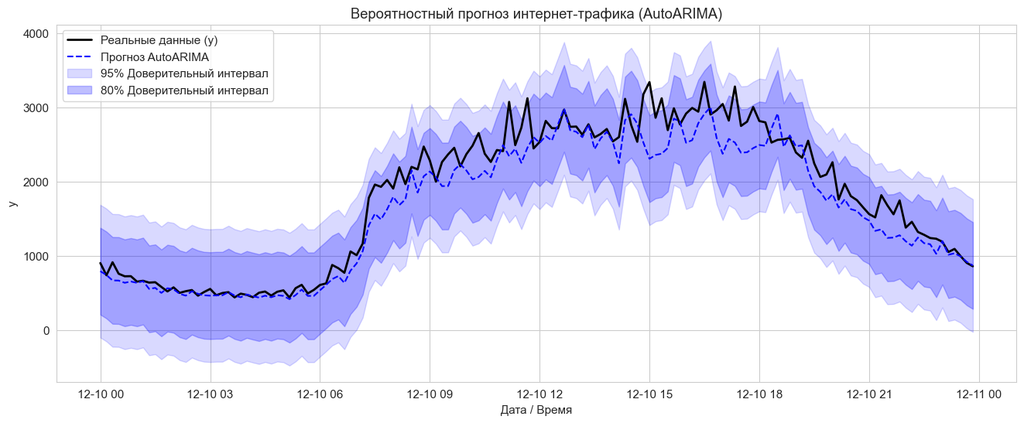

```python
print("→ Генерация вероятностного прогноза (Доверительные интервалы)")

# Задаем уровни доверия (80% и 95%)
levels = [80, 95]

# Генерируем прогноз с интервалами
df_prob_forecast = sf.forecast(df=df_train, h=horizon, level=levels, X_df=X_df_test)
df_prob_eval = df_test.merge(df_prob_forecast, on=['unique_id', 'ds'])

# Визуализация модели, например, AutoARIMA с интервалами неопределенности
plt.figure(figsize=(16, 6))
plt.plot(df_prob_eval['ds'], df_prob_eval['y'], label='Реальные данные (y)', color='black', lw=2)
plt.plot(df_prob_eval['ds'], df_prob_eval['AutoARIMA'], label='Прогноз AutoARIMA', color='blue', linestyle='--')

# Заливка доверительных интервалов
plt.fill_between(
    df_prob_eval['ds'],
    df_prob_eval['AutoARIMA-lo-95'],
    df_prob_eval['AutoARIMA-hi-95'],
    alpha=0.15, color='blue', label='95% Доверительный интервал'
)
plt.fill_between(
    df_prob_eval['ds'],
    df_prob_eval['AutoARIMA-lo-80'],
    df_prob_eval['AutoARIMA-hi-80'],
    alpha=0.25, color='blue', label='80% Доверительный интервал'
)

plt.title('Вероятностный прогноз интернет-трафика (AutoARIMA)')
plt.xlabel('Дата / Время')
plt.ylabel('y')
plt.legend()
plt.show()
```

## Статистика

```
→ Анализ остатков на тестовом окне
```

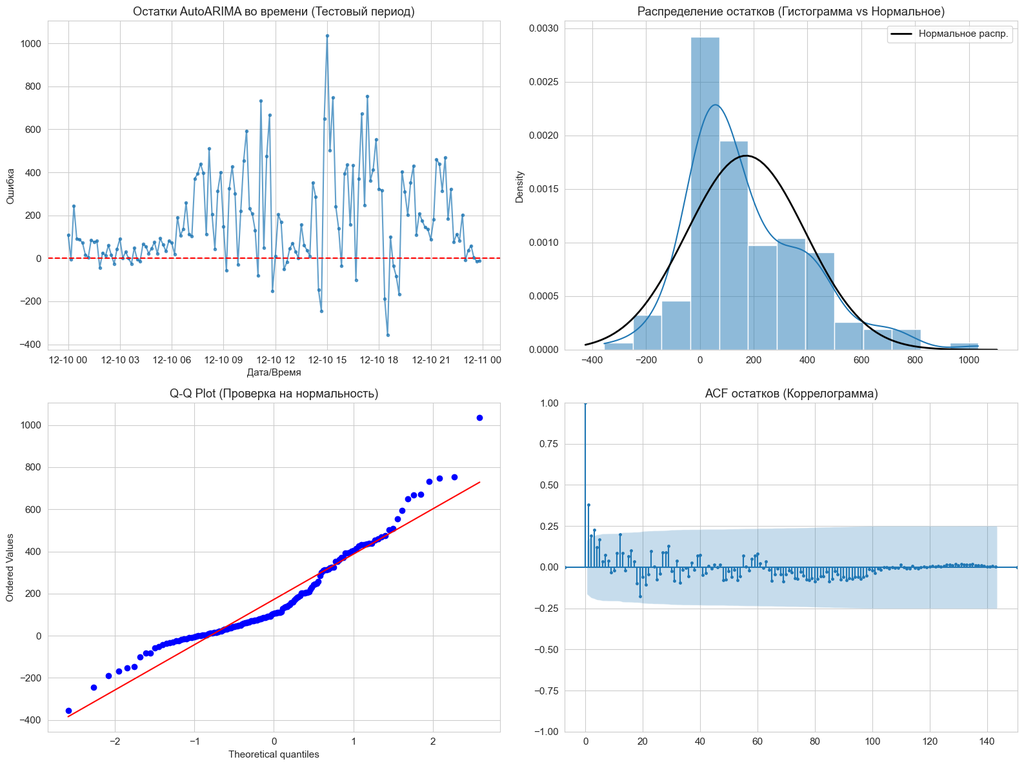

```
→ Статистический тест Льюнга-Бокса на независимость остатков
Результаты теста Льюнга-Бокса:
      lb_stat     lb_pvalue
6   41.584537  2.220859e-07
24  65.708047  9.577635e-06

p-value на максимальном проверенном лаге: 9.57763493954285e-06
ВЫВОД: В остатках присутствует автокорреляция. Модель упустила часть системной информации (возможно, требуются дополнительные лаги или экзогенные признаки).
```

```python
import scipy.stats as stats
from statsmodels.graphics.tsaplots import plot_acf
from statsmodels.stats.diagnostic import acorr_ljungbox

print("→ Анализ остатков на тестовом окне")

chosen_model = 'AutoARIMA'

# Расчет остатков (ошибок прогноза)
residuals = df_eval['y'] - df_eval[chosen_model]

fig, axes = plt.subplots(2, 2, figsize=(16, 12))
# График остатков во времени
axes[0, 0].plot(df_eval['ds'], residuals, marker='.', linestyle='-', alpha=0.7)
axes[0, 0].axhline(0, color='red', linestyle='--')
axes[0, 0].set_title(f'Остатки {chosen_model} во времени (Тестовый период)')
axes[0, 0].set_xlabel('Дата/Время')
axes[0, 0].set_ylabel('Ошибка')

# Гистограмма распределения остатков и кривая нормального распределения
sns.histplot(residuals, kde=True, ax=axes[0, 1], stat="density")
# Нормальное распределение для сравнения
xmin, xmax = axes[0, 1].get_xlim()
x = np.linspace(xmin, xmax, 100)
p = stats.norm.pdf(x, residuals.mean(), residuals.std())
axes[0, 1].plot(x, p, 'k', linewidth=2, label='Нормальное распр.')
axes[0, 1].set_title('Распределение остатков (Гистограмма vs Нормальное)')
axes[0, 1].legend()

# График Квантиль-Квантиль (Q-Q plot) для проверки нормальности
stats.probplot(residuals, dist="norm", plot=axes[1, 0])
axes[1, 0].set_title('Q-Q Plot (Проверка на нормальность)')

# Автокорреляционная функция остатков (ACF) для проверки на "Белый шум"
# Проверяем лаги в пределах 1 суток (144 интервала)
plot_acf(residuals, lags=SEASON-1, ax=axes[1, 1], marker='.', title="ACF остатков (Коррелограмма)")

plt.tight_layout()
plt.show()

print("\n→ Статистический тест Льюнга-Бокса на независимость остатков")
# Проверяем, есть ли взаимосвязь между остатками на ключевых лагах
lag_counts = [6, 24]  # например, 6 интервалов = 1 час, 24 интервала = 4 часа
lb_test = acorr_ljungbox(residuals, lags=lag_counts, return_df=True)

print("Результаты теста Льюнга-Бокса:")
print(lb_test)

# Интерпретация теста Льюнга-Бокса
p_val_key = lb_test['lb_pvalue'].iloc[-1]
print(f"\np-value на максимальном проверенном лаге: {p_val_key}")
if p_val_key > 0.05:
    print("ВЫВОД: Остатки являются независимыми (Белый шум). Модель полностью извлекла информацию из структуры ВР.")
else:
    print("ВЫВОД: В остатках присутствует автокорреляция. Модель упустила часть системной информации (возможно, требуются дополнительные лаги или экзогенные признаки).")
```

## Вывод

**Сравнительный анализ моделей**

С использованием фреймворка `StatsForecast` было проведено сравнение четырех моделей для временных рядов:

Неудачные прогнозы (Naive и AutoETS)

- Naive - модель просто "запоминает" последнее значение обучающей выборки и повторяет его на весь горизонт прогноза. Такой прогноз оказался полностью несостоятельным.
- AutoETS - при автоматическом подборе параметров модель, вероятно, выбрала неверные параметры, что привело к схлопыванию прогноза к среднему значению и потери чувствительности к колебаниям.

**Результаты бектестинга**

Основываясь на результатах бектестинга, в качестве финальной модели для прогнозирования временного ряда `square_id` `5200` следует выбрать `AutoARIMA`.

- Наилучшую точность среди всех рассматриваемых аналогов. Способность моделировать суточную сезонность телекоммуникационного трафика.

**Тест Льюнга-Бокса (Ljung-Box) для остатков модели AutoARIMA**

Результаты теста:

| Лаг | lb_stat | lb_pvalue |
| --- | --- | --- |
| 6 | 41.58 | 2.22e-07 |
| 24 | 65.71 | 9.58e-06 |

H0/H1

- Нулевая гипотеза (H0): остатки являются «белым шумом» (нет автокорреляции)
- Альтернативная гипотеза (H1): в остатках присутствует автокорреляция

**Результат:** p-value < 0.05 на всех проверенных лагах (6 и 24). Следовательно, **нулевая гипотеза отвергается**.

**Вывод:** В остатках модели **AutoARIMA присутствует статистически значимая автокорреляция** (p-value ≈ 9.58e-06). Это означает, что модель не полностью извлекла всю доступную структуру из данных. Часть системной информации осталась в остатках, что предположительно указывает на возможность улучшения модели (хотя уже в модели учитываются, выходные, holidays).

**Важное уточнение:** Несмотря на то, что визуально прогнозы AutoARIMA выглядят лучше других моделей, статистический тест показывает, что **модель недообучена**. Это противоречие между визуальным качеством и статистическими тестами — важный индикатор того, что для данной задачи требуется более сложная модель или дополнительная предобработка признаков.

# Задача №3

```python
import pandas as pd
import holidays

file_path = 'data/telecom_square_5200_cleaned.csv'
df_ts = pd.read_csv(file_path, index_col=False)
try:
    df_ts = df_ts.drop(columns='Unnamed: 0')
except:
    pass
# Данные под Nixtla
df_ts['ds'] = pd.to_datetime(df_ts['ds'])
df_ts['y'] = df_ts['y'].astype(float)
df_ts['unique_id'] = df_ts['unique_id'].astype(int)

# Дополнение признаками
df_ts.set_index('ds', inplace=True)
df_ts['hour'] = df_ts.index.hour
df_ts['day_of_week'] = df_ts.index.dayofweek
df_ts['day'] = df_ts.index.day
df_ts['week'] = df_ts.index.isocalendar().week
df_ts['month'] = df_ts.index.month
df_ts['is_weekend'] = df_ts['day_of_week'].isin([5, 6]).astype(int)
it_holidays = holidays.IT(years=[2013, 2014])
df_ts['is_holiday'] = df_ts.index.to_series().dt.date.apply(lambda x: x in it_holidays).astype(int)

df_ts = df_ts.reset_index()

start_date = '2013-11-04'
mid_date = '2013-12-10'
end_date = pd.to_datetime(mid_date) + pd.Timedelta(days=1)

df_ts = df_ts[(start_date <= df_ts['ds']) & (df_ts['ds'] < end_date)].reset_index(drop=True)

df_ts.head()
```

|  | ds | y | unique_id | hour | day_of_week | day | week | month | is_weekend | is_holiday |
| --- | --- | --- | --- | --- | --- | --- | --- | --- | --- | --- |
| 0 | 2013-11-04 00:00:00 | 646.695936 | 5200 | 0 | 0 | 4 | 45 | 11 | 0 | 0 |
| 1 | 2013-11-04 00:10:00 | 682.688973 | 5200 | 0 | 0 | 4 | 45 | 11 | 0 | 0 |
| 2 | 2013-11-04 00:20:00 | 640.407509 | 5200 | 0 | 0 | 4 | 45 | 11 | 0 | 0 |
| 3 | 2013-11-04 00:30:00 | 842.972689 | 5200 | 0 | 0 | 4 | 45 | 11 | 0 | 0 |
| 4 | 2013-11-04 00:40:00 | 661.532571 | 5200 | 0 | 0 | 4 | 45 | 11 | 0 | 0 |

## Детекция аномалий во временном ряду

```
→ Выявление аномалий с помощью Isolation Forest
Выявлено выбросов: 54 из 5328
```

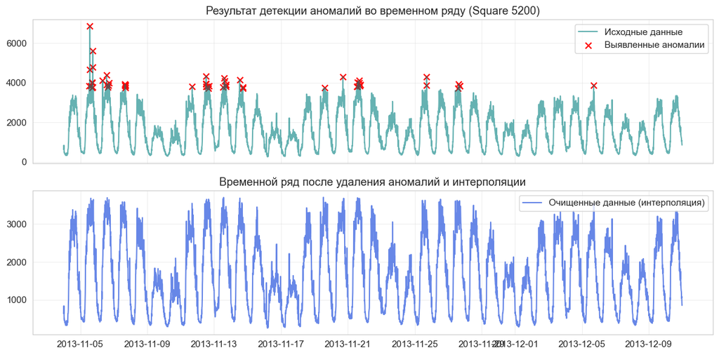

```python
import numpy as np
import pandas as pd
import matplotlib.pyplot as plt
import seaborn as sns
from sklearn.ensemble import IsolationForest

print("→ Выявление аномалий с помощью Isolation Forest")

# Для детекции аномалий используем целевую переменную
iso_forest = IsolationForest(contamination=0.01, random_state=42)
df_ts['anomaly'] = iso_forest.fit_predict(df_ts[['y']])

# Аномалии помечаются как -1
anomalies = df_ts[df_ts['anomaly'] == -1]
print(f"Выявлено выбросов: {len(anomalies)} из {len(df_ts)}")

# Визуализация аномалий
fig, axes = plt.subplots(2, 1, figsize=(12, 6), sharex=True)
axes[0].plot(df_ts['ds'], df_ts['y'], color='teal', alpha=0.6, label='Исходные данные')
axes[0].scatter(anomalies['ds'], anomalies['y'], color='red', marker='x', s=50, label='Выявленные аномалии')
axes[0].set_title('Результат детекции аномалий во временном ряду (Square 5200)')
axes[0].legend()
axes[0].grid(True, alpha=0.3)

# Очистка: Заменяем аномальные выбросы линейной интерполяцией, чтобы не сбивать ML-модели
df_ts_clean = df_ts.copy()
df_ts_clean.loc[df_ts_clean['anomaly'] == -1, 'y'] = np.nan
df_ts_clean['y'] = df_ts_clean['y'].interpolate(method='linear')

axes[1].plot(df_ts_clean['ds'], df_ts_clean['y'], color='royalblue', alpha=0.8, label='Очищенные данные (интерполяция)')
axes[1].set_title('Временной ряд после удаления аномалий и интерполяции')
axes[1].legend()
axes[1].grid(True, alpha=0.3)

# Оптимизация расстояния между графиками и вывод
plt.tight_layout()
plt.show()
```

## Feature Engineering и инициализация фреймворка MLForecast

```python
from mlforecast import MLForecast
from mlforecast.target_transforms import Differences
from mlforecast.utils import PredictionIntervals
from window_ops.rolling import rolling_mean, rolling_std
from lightgbm import LGBMRegressor
from xgboost import XGBRegressor

# Настройка параметров Feature Engineering
SEASON = 144 # 1 сутки
horizon = SEASON
rnd_id = 1

# Разделение очищенных данных на Train/Test (аналогично Задаче №2)
df_ml_train = df_ts_clean[(start_date <= df_ts_clean['ds']) & (df_ts_clean['ds'] < mid_date)].copy()
df_ml_test = df_ts_clean[(mid_date <= df_ts_clean['ds']) & (df_ts_clean['ds'] < end_date)].copy()
```

```python
# Инициализируем MLForecast
models = {
        'LightGBM': LGBMRegressor(
            random_state=rnd_id,
            n_estimators=150,
            learning_rate=0.05
            ),
        'XGBoost': XGBRegressor(
            random_state=rnd_id,
            n_estimators=150,
            learning_rate=0.05
            )
    }

date_features = [
    'hour',           # час дня (0-23)
    'day_of_week',    # день недели (0-6)
    'month',          # месяц (1-12)
    'day',            # день месяца
    'week',           # неделя года
    'is_holiday'
]

lags = [
    1, 2, 3,                            # ближайшие лаги
    SEASON - 1, SEASON, SEASON + 1,     # суточная сезонность
    SEASON * 2,                         # двухсуточная сезонность (!?!??!?)
]

lag_transforms={
        1: [(rolling_mean, 6), (rolling_std, 6)], # Статистика за последний час (6 интервалов по 10 мин)
        SEASON: [(rolling_mean, SEASON)]          # Статистика за прошлые сутки
    }

mlf = MLForecast(
    models=models,
    freq='10min',
    lags=lags,
    lag_transforms=lag_transforms,
    # date_features=date_features,
    num_threads=-1
)

# Обучение моделей с автоматической генерацией признаков внутри фреймворка
print("→ Обучение моделей машинного обучения через MLForecast")
mlf.fit(
    df_ml_train,
    static_features=[],
    prediction_intervals = PredictionIntervals(n_windows=5, h=horizon)  # Для Дов.Интервала
)
```

```
→ Обучение моделей машинного обучения через MLForecast
[LightGBM] [Info] Auto-choosing col-wise multi-threading, the overhead of testing was 0.000415 seconds.
You can set `force_col_wise=true` to remove the overhead.
[LightGBM] [Info] Total Bins 2625
[LightGBM] [Info] Number of data points in the train set: 4176, number of used features: 17
[LightGBM] [Info] Start training from score 1660.727034
```

```
[LightGBM] [Info] Auto-choosing col-wise multi-threading, the overhead of testing was 0.000391 seconds.
You can set `force_col_wise=true` to remove the overhead.
[LightGBM] [Info] Total Bins 2629
[LightGBM] [Info] Number of data points in the train set: 4896, number of used features: 18
[LightGBM] [Info] Start training from score 1634.655594
```

```
MLForecast(models=[LightGBM, XGBoost], freq=10min, lag_features=['lag1', 'lag2', 'lag3', 'lag143', 'lag144', 'lag145', 'lag288', 'rolling_mean_lag1_window_size6', 'rolling_std_lag1_window_size6', 'rolling_mean_lag144_window_size144'], date_features=[], num_threads=12)
```

```python
# Генерация прогноза на горизонт в 1 сутки
X_future = df_ml_test[[col for col in df_ml_test.columns if col != 'y']]
df_ml_forecast = mlf.predict(horizon, X_df=X_future)

# Объединение для валидации
df_ml_eval = df_ml_test.merge(df_ml_forecast, on=['unique_id', 'ds'])
df_ml_eval.head()
```

|  | ds | y | unique_id | hour | day_of_week | day | week | month | is_weekend | is_holiday | anomaly | LightGBM | XGBoost |
| --- | --- | --- | --- | --- | --- | --- | --- | --- | --- | --- | --- | --- | --- |
| 0 | 2013-12-10 00:00:00 | 900.766381 | 5200 | 0 | 1 | 10 | 50 | 12 | 0 | 0 | 1 | 786.537952 | 750.909790 |
| 1 | 2013-12-10 00:10:00 | 735.569373 | 5200 | 0 | 1 | 10 | 50 | 12 | 0 | 0 | 1 | 763.886903 | 734.952393 |
| 2 | 2013-12-10 00:20:00 | 911.667448 | 5200 | 0 | 1 | 10 | 50 | 12 | 0 | 0 | 1 | 740.037179 | 705.477234 |
| 3 | 2013-12-10 00:30:00 | 756.652489 | 5200 | 0 | 1 | 10 | 50 | 12 | 0 | 0 | 1 | 737.108266 | 669.426392 |
| 4 | 2013-12-10 00:40:00 | 722.218302 | 5200 | 0 | 1 | 10 | 50 | 12 | 0 | 0 | 1 | 728.544605 | 653.020203 |

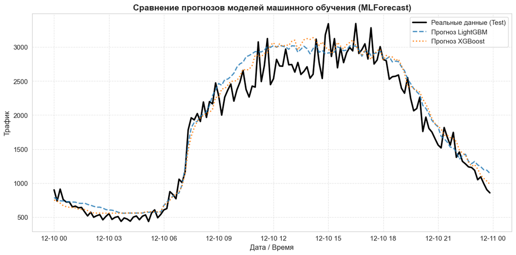

```python
import matplotlib.pyplot as plt

# Сортируем данные по времени
df_plot = df_ml_eval.sort_values('ds').head(144)

plt.figure(figsize=(12, 6))

# Реальные данные
plt.plot(df_plot['ds'], df_plot['y'], label='Реальные данные (Test)', color='black', linewidth=2.5)

# Прогноз LightGBM
if 'LightGBM' in df_plot.columns:
    plt.plot(df_plot['ds'], df_plot['LightGBM'], label='Прогноз LightGBM', linestyle='--', alpha=0.8, linewidth=2)

# Прогноз XGBoost
if 'XGBoost' in df_plot.columns:
    plt.plot(df_plot['ds'], df_plot['XGBoost'], label='Прогноз XGBoost', linestyle=':', alpha=0.9, linewidth=2)

plt.title("Сравнение прогнозов моделей машинного обучения (MLForecast)", fontsize=14, fontweight='bold')
plt.xlabel("Дата / Время", fontsize=12)
plt.ylabel("Трафик", fontsize=12)
plt.legend(fontsize=11)
plt.grid(True, linestyle='--', alpha=0.5)

plt.tight_layout()
plt.show()
```

Оценка точности и сравнение

```python
from utilsforecast.losses import mae, rmse
from utilsforecast.evaluation import evaluate

print("→ Метрики точности ML-моделей")
ml_metrics = evaluate(
    df_ml_eval,
    metrics=[mae, mse, rmse],
    models=['LightGBM', 'XGBoost']
)
display(ml_metrics)
```

```
→ Метрики точности ML-моделей
```

|  | unique_id | metric | LightGBM | XGBoost |
| --- | --- | --- | --- | --- |
| 0 | 5200 | mae | 171.988132 | 165.622828 |
| 1 | 5200 | mse | 47060.534709 | 47587.770860 |
| 2 | 5200 | rmse | 216.934402 | 218.146214 |

## Доверительный интервал (XGBoost)

Для модели построим доверительные интервалы (80% и 95%).

```
→ Генерация вероятностного прогноза (Доверительные интервалы)
```

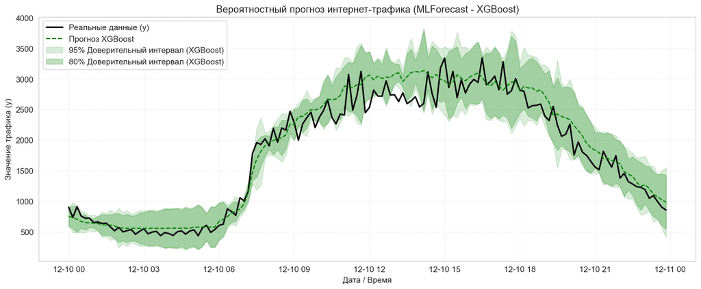

```python
print("→ Генерация вероятностного прогноза (Доверительные интервалы)")

# Задаем уровни доверия (80% и 95%)
levels = [80, 95]

df_prob_forecast = mlf.predict(h=horizon, level=levels, X_df=X_future)
df_prob_eval = df_ml_test.merge(df_prob_forecast, on=['unique_id', 'ds'])

plt.figure(figsize=(16, 6))

# Построение реальных данных и точечного прогноза XGBoost
plt.plot(df_prob_eval['ds'], df_prob_eval['y'], label='Реальные данные (y)', color='black', lw=2)
plt.plot(df_prob_eval['ds'], df_prob_eval['XGBoost'], label='Прогноз XGBoost', color='green', linestyle='--')

# Заливка доверительных интервалов для XGBoost
# 95% интервал
plt.fill_between(
    df_prob_eval['ds'],
    df_prob_eval['XGBoost-lo-95'],
    df_prob_eval['XGBoost-hi-95'],
    alpha=0.15, color='green', label='95% Доверительный интервал (XGBoost)'
)

# 80% интервал
plt.fill_between(
    df_prob_eval['ds'],
    df_prob_eval['XGBoost-lo-80'],
    df_prob_eval['XGBoost-hi-80'],
    alpha=0.25, color='green', label='80% Доверительный интервал (XGBoost)'
)

plt.title('Вероятностный прогноз интернет-трафика (MLForecast - XGBoost)')
plt.xlabel('Дата / Время')
plt.ylabel('Значение трафика (y)')
plt.legend()
plt.grid(True, linestyle=':', alpha=0.6)
plt.show()
```

CV

```python
res_cv = mlf.cross_validation(
    df=df_ts_clean,
    n_windows=5,
    h=horizon,
    step_size=SEASON,
    static_features=[]
)

display(res_cv.head())
```

[output not shown]

|  | unique_id | ds | cutoff | y | LightGBM | XGBoost |
| --- | --- | --- | --- | --- | --- | --- |
| 0 | 5200 | 2013-12-06 00:00:00 | 2013-12-05 23:50:00 | 910.252147 | 829.587099 | 838.466614 |
| 1 | 5200 | 2013-12-06 00:10:00 | 2013-12-05 23:50:00 | 844.221237 | 799.144318 | 822.732422 |
| 2 | 5200 | 2013-12-06 00:20:00 | 2013-12-05 23:50:00 | 786.175901 | 786.230753 | 806.661499 |
| 3 | 5200 | 2013-12-06 00:30:00 | 2013-12-05 23:50:00 | 807.818312 | 780.082705 | 788.252197 |
| 4 | 5200 | 2013-12-06 00:40:00 | 2013-12-05 23:50:00 | 731.427567 | 767.707618 | 758.866394 |

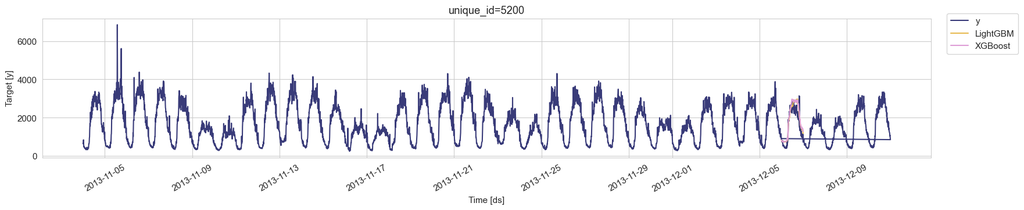

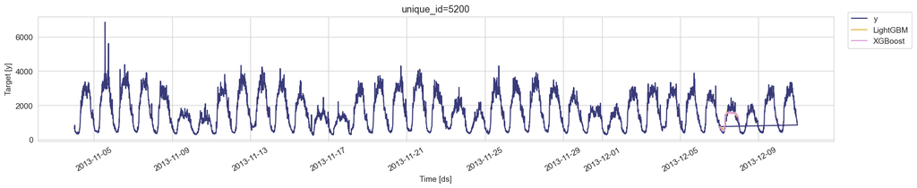

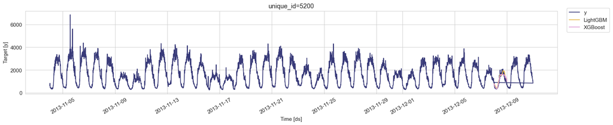

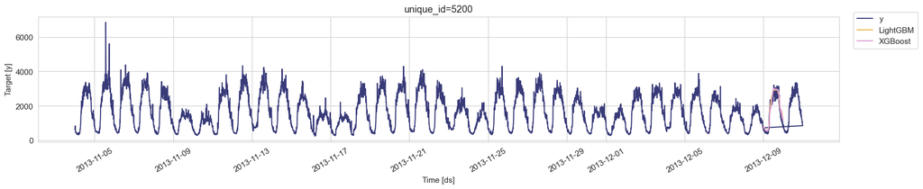

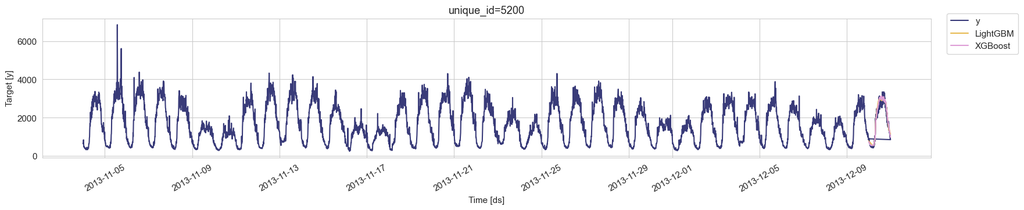

```python
cutoff = res_cv['cutoff'].unique()

for k in range(len(cutoff)):
    cv = res_cv[res_cv['cutoff'] == cutoff[k]]
    display(StatsForecast.plot(df_ts, cv.loc[:, cv.columns != 'cutoff']))
```

```python
print("Метрики для каждого фолда по отдельности:")
def evaluate_performance(df):
    metrics = [mae, mse, rmse]
    models_list = ['LightGBM', 'XGBoost']
    return evaluate(df, metrics=metrics, models=models_list)

# Считаем метрики по фолдам
cv_results = res_cv.groupby('cutoff').apply(evaluate_performance).reset_index(level=0, drop=True)
display(cv_results)

print("\nУсредненные метрики по итогам бектестинга:")
# Группируем по метрике, чтобы посчитать среднее отдельно для MAE, MSE и RMSE
mean_metrics = cv_results.groupby('metric').mean(numeric_only=True)
display(mean_metrics)
```

```
Метрики для каждого фолда по отдельности:
```

|  | unique_id | cutoff | metric | LightGBM | XGBoost |
| --- | --- | --- | --- | --- | --- |
| 0 | 5200 | 2013-12-05 23:50:00 | mae | 288.423644 | 320.776977 |
| 1 | 5200 | 2013-12-05 23:50:00 | mse | 122830.497538 | 145902.057998 |
| 2 | 5200 | 2013-12-05 23:50:00 | rmse | 350.471821 | 381.971279 |
| 0 | 5200 | 2013-12-06 23:50:00 | mae | 195.572136 | 176.598718 |
| 1 | 5200 | 2013-12-06 23:50:00 | mse | 56658.988935 | 51935.756736 |
| 2 | 5200 | 2013-12-06 23:50:00 | rmse | 238.031487 | 227.894179 |
| 0 | 5200 | 2013-12-07 23:50:00 | mae | 187.106027 | 146.279337 |
| 1 | 5200 | 2013-12-07 23:50:00 | mse | 52696.624695 | 36634.943214 |
| 2 | 5200 | 2013-12-07 23:50:00 | rmse | 229.557454 | 191.402568 |
| 0 | 5200 | 2013-12-08 23:50:00 | mae | 220.419549 | 219.817193 |
| 1 | 5200 | 2013-12-08 23:50:00 | mse | 70608.237169 | 67266.434740 |
| 2 | 5200 | 2013-12-08 23:50:00 | rmse | 265.722105 | 259.357735 |
| 0 | 5200 | 2013-12-09 23:50:00 | mae | 171.988132 | 165.622828 |
| 1 | 5200 | 2013-12-09 23:50:00 | mse | 47060.534709 | 47587.770860 |
| 2 | 5200 | 2013-12-09 23:50:00 | rmse | 216.934402 | 218.146214 |

```
Усредненные метрики по итогам бектестинга:
```

| metric | unique_id | LightGBM | XGBoost |
| --- | --- | --- | --- |
| mae | 5200.0 | 212.701898 | 205.819010 |
| mse | 5200.0 | 69970.976609 | 69865.392710 |
| rmse | 5200.0 | 260.143454 | 255.754395 |

## Статистика

```
→ Анализ остатков на тестовом окне
```

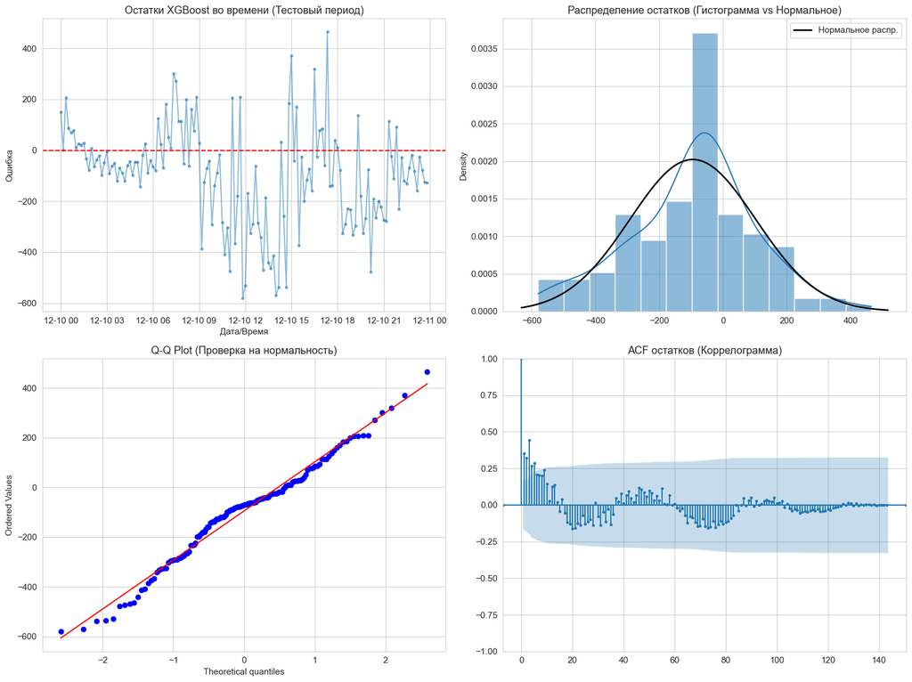

```
→ Статистический тест Льюнга-Бокса на независимость остатков
Результаты теста Льюнга-Бокса:
       lb_stat     lb_pvalue
6    92.332461  9.924037e-18
24  144.669590  3.217213e-19

p-value на максимальном проверенном лаге (24): 3.21721316551446e-19
ВЫВОД: В остатках присутствует автокорреляция. Модель упустила часть системной информации (возможно, требуются дополнительные лаги или экзогенные признаки).
```

```python
import scipy.stats as stats
from statsmodels.graphics.tsaplots import plot_acf
from statsmodels.stats.diagnostic import acorr_ljungbox

print("→ Анализ остатков на тестовом окне")

chosen_model = 'XGBoost'
# chosen_model = 'LightGBM'

# Расчет остатков (ошибок прогноза)
residuals = df_prob_eval['y'] - df_prob_eval[chosen_model]

fig, axes = plt.subplots(2, 2, figsize=(16, 12))

# График остатков во времени
axes[0, 0].plot(df_prob_eval['ds'], residuals, marker='.', linestyle='-', alpha=0.5)
axes[0, 0].axhline(0, color='red', linestyle='--')
axes[0, 0].set_title(f'Остатки {chosen_model} во времени (Тестовый период)')
axes[0, 0].set_xlabel('Дата/Время')
axes[0, 0].set_ylabel('Ошибка')

# Гистограмма распределения остатков и кривая нормального распределения
sns.histplot(residuals, kde=True, ax=axes[0, 1], stat="density")
xmin, xmax = axes[0, 1].get_xlim()
x = np.linspace(xmin, xmax, 100)
p = stats.norm.pdf(x, residuals.mean(), residuals.std())
axes[0, 1].plot(x, p, 'k', linewidth=2, label='Нормальное распр.')
axes[0, 1].set_title('Распределение остатков (Гистограмма vs Нормальное)')
axes[0, 1].legend()

# График Квантиль-Квантиль (Q-Q plot)
stats.probplot(residuals, dist="norm", plot=axes[1, 0])
axes[1, 0].set_title('Q-Q Plot (Проверка на нормальность)')

# Автокорреляционная функция остатков (ACF)
# Используем SEASON-1 из ваших глобальных настроек (суточная сезонность)
plot_acf(residuals, lags=SEASON-1, ax=axes[1, 1], marker='.', title="ACF остатков (Коррелограмма)")

plt.tight_layout()
plt.show()

print("\n→ Статистический тест Льюнга-Бокса на независимость остатков")
# Настройки лагов: 6 интервалов по 10 минут = 1 час, 24 интервала = 4 часа
lag_counts = [6, 24]
lb_test = acorr_ljungbox(residuals, lags=lag_counts, return_df=True)

print("Результаты теста Льюнга-Бокса:")
print(lb_test)

# Интерпретация теста Льюнга-Бокса
p_val_key = lb_test['lb_pvalue'].iloc[-1]
print(f"\np-value на максимальном проверенном лаге ({lag_counts[-1]}): {p_val_key}")
if p_val_key > 0.05:
    print("ВЫВОД: Остатки являются независимыми (Белый шум). Модель полностью извлекла информацию из структуры ВР.")
else:
    print("ВЫВОД: В остатках присутствует автокорреляция. Модель упустила часть системной информации (возможно, требуются дополнительные лаги или экзогенные признаки).")
```

## Вывод

Применение Data-Driven фреймворка `MLForecast` и моделей градиентного бустинга позволило значительно гибче аппроксимировать нелинейную структуру временного ряда по сравнению с классическими статистическими подходами из Задачи №2. Предварительная фильтрация импульсных выбросов с помощью алгоритма `Isolation Forest` снизила зашумленность сигнала, что позволило моделям точнее настроить древесные ансамбли на воспроизведение суточных колебаний интернет-активности абонентов в пиковые часы нагрузки (ЧНН) и ночные спады.

Таким образом, несмотря на высокое визуальное качество прогнозов и явное преимущество моделей машинного обучения над базовым уровнем, математический анализ остатков фиксирует состояние недообученности. Полученный результат является классическим индикатором того, что для полного исчерпания автокорреляции на высокоинтенсивных телеком-данных требуется дальнейшее усложнение архитектуры: либо расширение горизонта лагов (включение долгосрочной недельной сезонности $I = 1008$), либо обогащение модели дополнительными внешними признаками, либо переход к глубоким нейросетевым подходам.

# Задача №4

Решение в only_models.ipynb